## 2.A

SD = sqrt(sum of (mean - xi) ^ 2 / n)

```r
sqrt(((3-1)^2*1 + (3-2)^2*2 + (3-3)^2*3 + (3-4)^2*4) / 10)
```

```
## [1] 1
```

## 2.B

```r
2 / 10 + 4 / 10
```

```
## [1] 0.6
```

## 2.C

Case: (1,2), (1,3), (1,4), (2,3), (2,4), (3,4)

```r
1/10*2/10 + 1/10*3/10 + 1/10*4/10 + 2/10*3/10 + 2/10*4/10 + 3/10*4/10
```

```
## [1] 0.35
```

## 3.A

Each cases are independent, so each ball has a probability 1/3. The expected values of W, X, Y, Z are the same as

```r
A = 1*1/3 + 2*1/3 + 3*1/3
A
```

```
## [1] 2
```

```r
4 * A
```

```
## [1] 8
```

## 3.B

VAR(W + X + Y + Z) = VAR(W) + VAR(X) + VAR(Y) + VAR(Z) = sigma^2 + sigma^2 + sigma^2 + sigma^2 = 4*sigma^2

## 4

Mean = 14.7 amps, SD = 0.1 amps

### A

The point of 20% of larger tripping current = the point of 80% of smaller tripping current

```r
qnorm(p=0.8, mean=14.7, sd=0.1)
```

```
## [1] 14.78416
```

### B

between 14.5 and 14.9 amps is

```r
pnorm(q=14.9, mean=14.7, sd=0.1) - pnorm(14.5, mean=14.7, sd=0.1)
```

```
## [1] 0.9544997
```

## 5

60 samples, collected samples are independent N~(1, 0.2^2)

### A

60 samples within 55 minutes = 1 sample within 55/60 minutes

```r
pnorm(q = 55/60, mean=1, sd=0.2)
```

```
## [1] 0.3384611
```

### B

error = 0.02, errors are independent. Expected number of errors she will make when collecting all 60 samples is

```r
60 * 0.02
```

```
## [1] 1.2
```

### C

The probability she makes no errors in collecting all 60 samples is

```r
(1-0.02) ^ 60
```

```
## [1] 0.2975531
```

## 6

A survey is sent to randomly-selected students. All decisions are independent the probability that a student responds to the survey is ‘a’ the probability that a student answers 1 in the survey is ‘b’

## 7

randomly selects 20 students result = 57.6, 83.2, 62.0, 62.3, 53.2, 67.7, 67.4, 64.7, 69.1, 73.6, 63.5, 59.1, 63.5, 70.1, 68.7, 64.1, 80.0, 72.9, 74.3, 67.5

```r
result = c(57.6, 83.2, 62.0, 62.3, 53.2, 67.7, 67.4, 64.7, 69.1, 73.6, 63.5, 59.1, 63.5, 70.1, 68.7, 64.1, 80.0, 72.9, 74.3, 67.5)
```

SD of the original is 8.0

### A

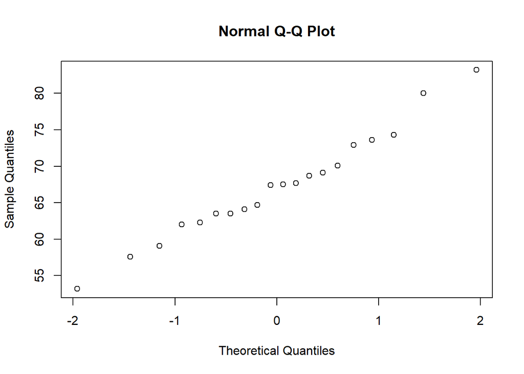

```r
qqnorm(result)
```

### B

Interval center = mean of the samples

```r
mean(result)
```

```
## [1] 67.225
```

### C

99% -> 1-a = 0.99 -> a = 0.01 Error margin = z(a/2) * sd / sqrt(n)

```r
qnorm(1-0.005) * 8.0 / sqrt(20)
```

```
## [1] 4.607784
```

### D

Make error margin 2.0 error margin = z(a/2) * sd / sqrt(n) -> sqrt(n) = z(a/2) * sd / errorMargin -> n = (z(a/2)*sd/errorMargin)^2

```r
(qnorm(1-0.005)*8.0/2.0)^2
```

```
## [1] 106.1583
```

Round up the result

## 8

## 9

## 10

Assume n is large enough.

A. The sample mean is same as the original sample mean according to the CLT.

- False

B. The sample standard deviation is sigma/sqrt(n), so when n increases, the sample standard deviation goes toward 0.

- True

C. The standard deviation of the sample mean is sqrt(sum of (xi - mu)^2 / n), and it goes toward 0 when n increases.

- True

D. The mean of the distribution of the sample mean will go toward the original sample mean when n increases.

- False

E. the standard deviation of the first item in the sample is undefined.

- False